# Exp. 1_behaviours

Gabriel Melhado

2026-07-17

Load the packages used for data manipulation, project-relative file paths, generalised linear mixed-effects models, residual diagnostics, estimated marginal means, plotting, and figure assembly. Using pacman::p_load() also installs packages that are not already available in the R library.

```r
# Load packages
pacman::p_load(tidyverse, here, glmmTMB, DHARMa, performance, broom.mixed, car, dplyr, emmeans, ggeffects, scales, patchwork)
```

```r
# Load Data
data <- read.csv(here("data", "exp1_data.csv"))
```

```r
# Factorise IDs + treatment
data <- data %>%
  mutate(
    Treatment = factor(Treatment),
    Tank_ID   = factor(Tank_ID),
    Fish_ID   = factor(Fish_ID),
    Batch     = factor(Batch),
    Trial     = factor(Trial),
    Arena     = factor(Arena)
  )
```

## Identify fish that did not emerge

Create a subset that excludes fish recorded as not emerging from the shelter, and compare the full and reduced sample sizes. This documents how many fish produced post-emergence behavioural observations and could be used in analyses that require emergence.

```r
# Create a subset excluding fish not came out
# Remove fish that did not come out of shelter
data_subset <- subset(data, notes != "not came out")

# Check sample size
nrow(data)        # 160
```

```
## [1] 160
```

```r
nrow(data_subset) # 126
```

```
## [1] 126
```

## Analyse emergence probability

Convert the emergence outcome into a binary variable, where fish that did not emerge are coded as 0 and all others as 1. Fit a binomial generalised linear mixed-effects model to test whether emergence probability differs among treatments while controlling for body mass and accounting for tank-level clustering. Estimated marginal means are then returned on the probability scale.

```r
data$emerged <- ifelse(data$notes == "not came out", 0, 1)

emergence_probability_model <- glmmTMB(emerged ~ Treatment + Body_mass + (1|Tank_ID),
        family = binomial,
        data = data)


summary(emergence_probability_model)
```

```
##  Family: binomial  ( logit )
## Formula:          emerged ~ Treatment + Body_mass + (1 | Tank_ID)
## Data: data
##
##      AIC      BIC   logLik deviance df.resid
##    172.9    188.3    -81.4    162.9      155
##
## Random effects:
##
## Conditional model:
##  Groups  Name        Variance Std.Dev.
##  Tank_ID (Intercept) 0.08731  0.2955
## Number of obs: 160, groups:  Tank_ID, 24
##
## Conditional model:
##                Estimate Std. Error z value Pr(>|z|)
## (Intercept)    2.145493   0.694110   3.091  0.00199 **
## TreatmentHigh  0.008245   0.494977   0.017  0.98671
## TreatmentLow   0.229594   0.511853   0.449  0.65375
## Body_mass     -1.413614   0.928424  -1.523  0.12786
## ---
## Signif. codes:  0 '***' 0.001 '**' 0.01 '*' 0.05 '.' 0.1 ' ' 1
```

```r
Anova(emergence_probability_model)
```

```
## Analysis of Deviance Table (Type II Wald chisquare tests)
##
## Response: emerged
##            Chisq Df Pr(>Chisq)
## Treatment 0.2543  2     0.8806
## Body_mass 2.3183  1     0.1279
```

```r
emm <- emmeans(emergence_probability_model, ~ Treatment)

summary(emm, type = "response")
```

```
##  Treatment  prob     SE  df asymp.LCL asymp.UCL
##  Control   0.783 0.0607 Inf     0.642     0.879
##  High      0.784 0.0616 Inf     0.640     0.881
##  Low       0.819 0.0579 Inf     0.678     0.907
##
## Confidence level used: 0.95
## Intervals are back-transformed from the logit scale
```

## Explore behavioural-variable distributions

Summarise and visualise the raw distributions of distance moved, freezing time, and time spent in the shelter. These descriptive statistics and histograms help identify skewness, zero inflation, boundary values, and other distributional features that inform the choice of statistical model.

```r
summary(data$Distance_moved)
```

```
##     Min.  1st Qu.   Median     Mean  3rd Qu.     Max.
##    0.000    5.537  159.601  351.890  500.176 2712.780
```

```r
summary(data$Time_not_moving)
```

```
##     Min.  1st Qu.   Median     Mean  3rd Qu.     Max.
##    0.000    2.992  111.916  261.366  390.474 1199.330
```

```r
summary(data$Time_shelter)
```

```
##    Min. 1st Qu.  Median    Mean 3rd Qu.    Max.
##     0.0   671.7  1052.0   882.7  1196.7  1200.0
```

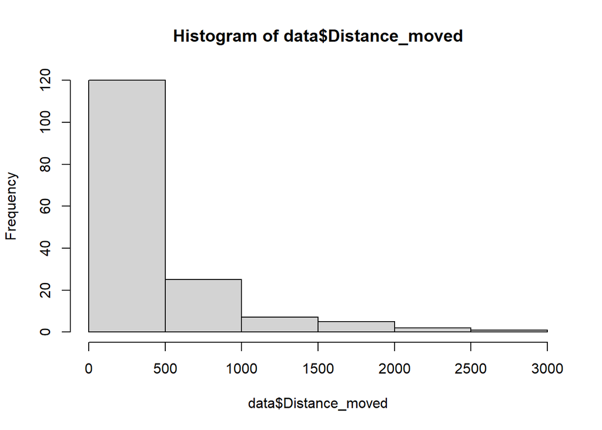

```r
hist(data$Distance_moved)
```

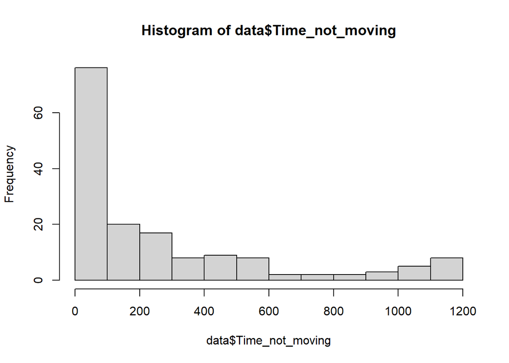

```r
hist(data$Time_not_moving)
```

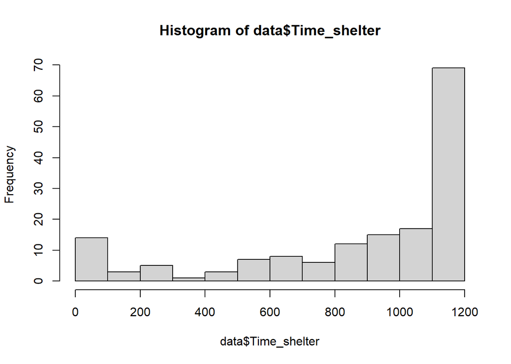

```r
hist(data$Time_shelter)
```

## Model distance moved

Fit a Tweedie generalised linear mixed-effects model for distance moved. Treatment and body mass are included as fixed effects, tank is included as a random intercept, and DHARMa simulation-based diagnostics are used to assess residual behaviour, dispersion, zero inflation, and outliers before testing the overall treatment effect.

```r
#Distance_moved
#Family tweedie
m2_distance_moved <- glmmTMB(Distance_moved ~ Treatment + Body_mass + (1 | Tank_ID),
  data = data,
  family = tweedie(link = "log"))

summary(m2_distance_moved)
```

```
##  Family: tweedie  ( log )
## Formula:          Distance_moved ~ Treatment + Body_mass + (1 | Tank_ID)
## Data: data
##
##      AIC      BIC   logLik deviance df.resid
##   1954.3   1975.8   -970.1   1940.3      153
##
## Random effects:
##
## Conditional model:
##  Groups  Name        Variance Std.Dev.
##  Tank_ID (Intercept) 0.04904  0.2214
## Number of obs: 160, groups:  Tank_ID, 24
##
## Dispersion parameter for tweedie family (): 14.8
##
## Conditional model:
##               Estimate Std. Error z value Pr(>|z|)
## (Intercept)    6.37803    0.39112  16.307   <2e-16 ***
## TreatmentHigh -0.35461    0.28670  -1.237    0.216
## TreatmentLow  -0.02045    0.27741  -0.074    0.941
## Body_mass     -0.71633    0.55420  -1.293    0.196
## ---
## Signif. codes:  0 '***' 0.001 '**' 0.01 '*' 0.05 '.' 0.1 ' ' 1
```

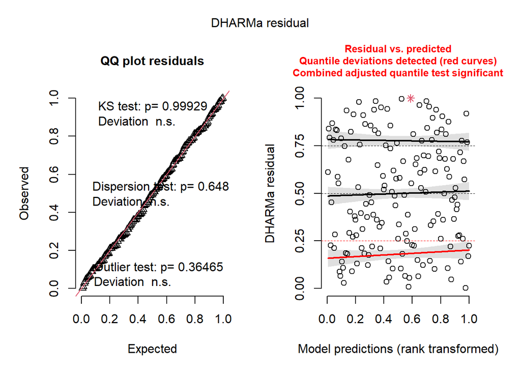

```r
# Diagnosis
res_m2_distance_moved <- simulateResiduals(m2_distance_moved)
plot(res_m2_distance_moved)
```

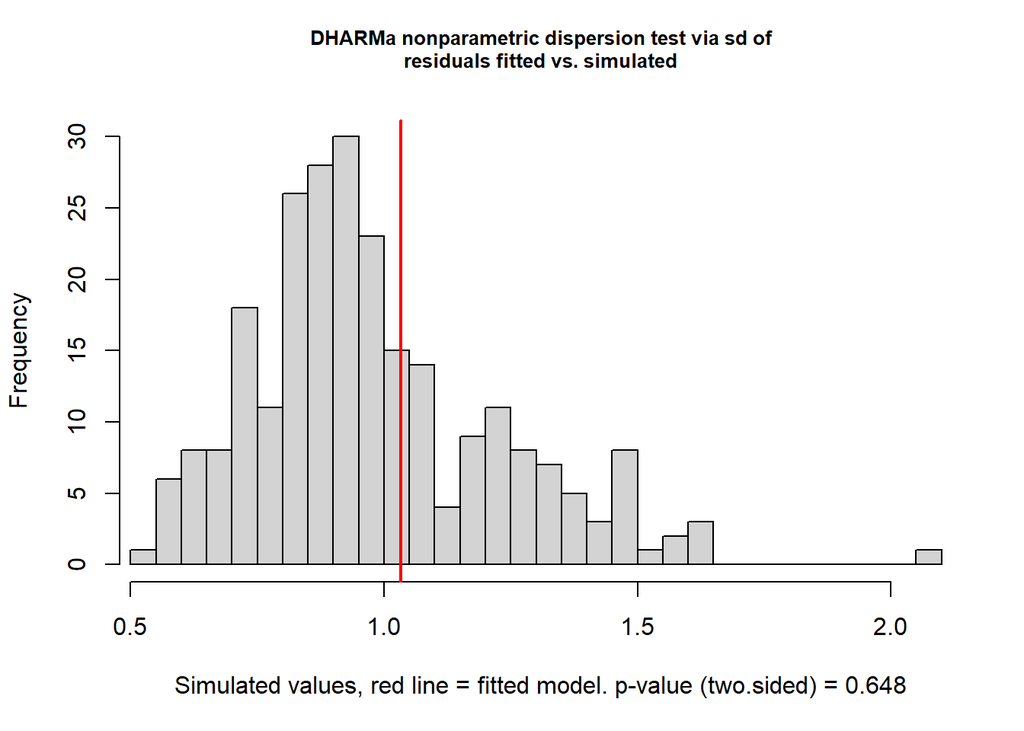

```
##
##  DHARMa nonparametric dispersion test via sd of residuals fitted vs.
##  simulated
##
## data:  simulationOutput
## dispersion = 1.0541, p-value = 0.648
## alternative hypothesis: two.sided
```

```r
testDispersion(res_m2_distance_moved)
```

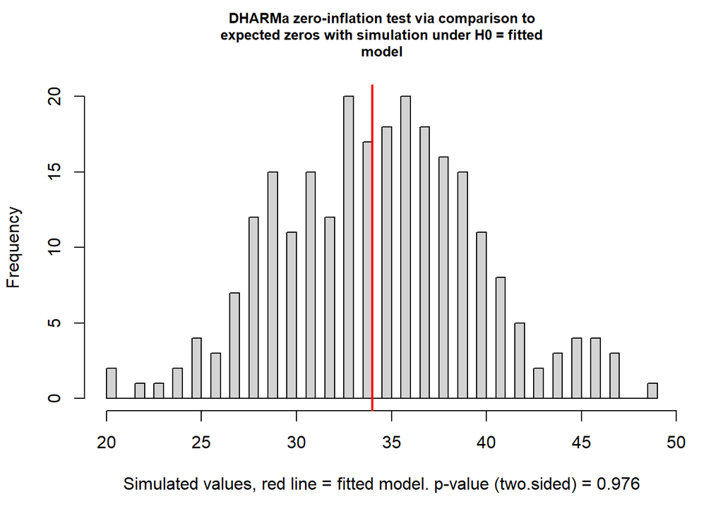

```
##
##  DHARMa zero-inflation test via comparison to expected zeros with
##  simulation under H0 = fitted model
##
## data:  simulationOutput
## ratioObsSim = 0.983, p-value = 0.976
## alternative hypothesis: two.sided
```

```r
testZeroInflation(res_m2_distance_moved)
```

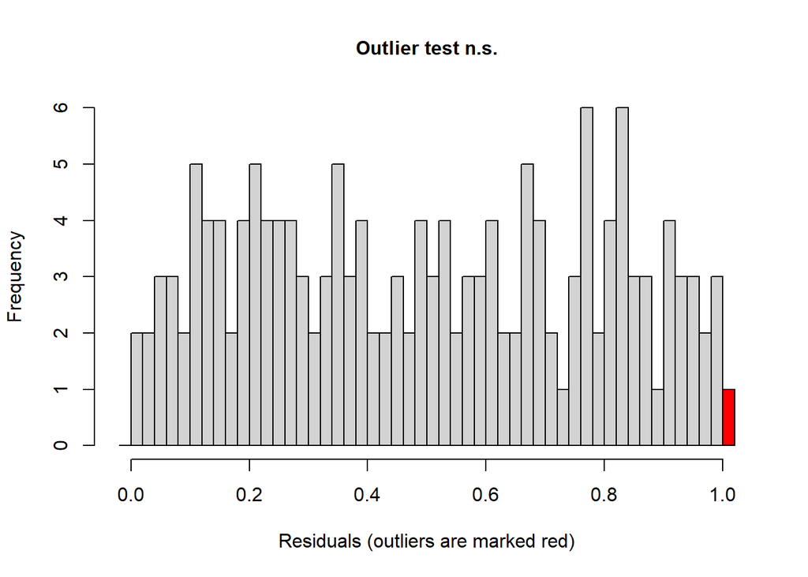

```
##
##  DHARMa outlier test based on exact binomial test with approximate
##  expectations
##
## data:  res_m2_distance_moved
## outliers at both margin(s) = 2, observations = 160, p-value = 0.3647
## alternative hypothesis: true probability of success is not equal to 0.007968127
## 95 percent confidence interval:
##  0.001517409 0.044423034
## sample estimates:
## frequency of outliers (expected: 0.00796812749003984 )
##                                                 0.0125
```

```r
testOutliers(res_m2_distance_moved)
```

```r
Anova(m2_distance_moved)
```

```
## Analysis of Deviance Table (Type II Wald chisquare tests)
##
## Response: Distance_moved
##            Chisq Df Pr(>Chisq)
## Treatment 1.8804  2     0.3906
## Body_mass 1.6707  1     0.1962
```

## Plot distance moved

```r
# Plotting Distance_moved

# 1) Ensure treatment order
data$Treatment <- factor(
  data$Treatment,
  levels = c("Control", "Low", "High")
)

# 2) Fit Tweedie model
m2_distance_moved <- glmmTMB(
  Distance_moved ~ Treatment + Body_mass + (1 | Tank_ID),
  data = data,
  family = tweedie(link = "log")
)

summary(m2_distance_moved)
```

```
##  Family: tweedie  ( log )
## Formula:          Distance_moved ~ Treatment + Body_mass + (1 | Tank_ID)
## Data: data
##
##      AIC      BIC   logLik deviance df.resid
##   1954.3   1975.8   -970.1   1940.3      153
##
## Random effects:
##
## Conditional model:
##  Groups  Name        Variance Std.Dev.
##  Tank_ID (Intercept) 0.04904  0.2214
## Number of obs: 160, groups:  Tank_ID, 24
##
## Dispersion parameter for tweedie family (): 14.8
##
## Conditional model:
##               Estimate Std. Error z value Pr(>|z|)
## (Intercept)    6.37803    0.39112  16.307   <2e-16 ***
## TreatmentLow  -0.02045    0.27741  -0.074    0.941
## TreatmentHigh -0.35461    0.28670  -1.237    0.216
## Body_mass     -0.71633    0.55420  -1.293    0.196
## ---
## Signif. codes:  0 '***' 0.001 '**' 0.01 '*' 0.05 '.' 0.1 ' ' 1
```

```r
# 3) Get marginal means on the response scale
emm_dist_df <- as.data.frame(
  emmeans(m2_distance_moved, ~ Treatment, type = "response")
)

print(emm_dist_df)
```

```
##  Treatment response       SE  df asymp.LCL asymp.UCL
##  Control   380.1215 75.25857 Inf  257.8676  560.3354
##  Low       372.4286 75.33911 Inf  250.5257  553.6481
##  High      266.6361 58.06943 Inf  173.9962  408.5998
##
## Confidence level used: 0.95
## Intervals are back-transformed from the log scale
```

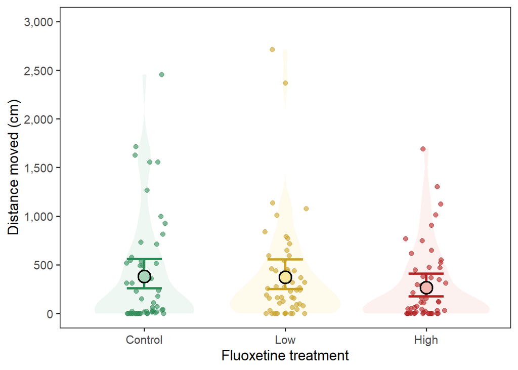

```r
# 4) Standardise column names
cn <- names(emm_dist_df)

mean_col  <- dplyr::first(cn[cn %in% c("response", "rate", "emmean")])
lower_col <- dplyr::first(cn[grepl("^lower\\.CL$|^asymp\\.LCL$|^LCL$|^lower$", cn)])
upper_col <- dplyr::first(cn[grepl("^upper\\.CL$|^asymp\\.UCL$|^UCL$|^upper$", cn)])

if (is.na(mean_col) || is.na(lower_col) || is.na(upper_col)) {
  stop("Could not identify mean/CI columns in emmeans output. Run names(emm_dist_df).")
}

emm_dist_df <- emm_dist_df %>%
  mutate(Treatment = factor(Treatment, levels = c("Control", "Low", "High"))) %>%
  rename(
    mean  = !!mean_col,
    lower = !!lower_col,
    upper = !!upper_col
  )

# 5) Palettes
pastel_cols <- c(
  "Control" = "#A8D5BA",
  "Low"     = "#F9E79F",
  "High"    = "#F5B7B1"
)

dark_cols <- c(
  "Control" = "#2E8B57",
  "Low"     = "#C9A227",
  "High"    = "#B22222"
)

# 6) Plot on original distance scale
p_distance <- ggplot() +
  geom_violin(
    data = data,
    aes(x = Treatment, y = Distance_moved, fill = Treatment),
    alpha = 0.20,
    colour = NA,
    trim = TRUE
  ) +
  geom_jitter(
    data = data,
    aes(x = Treatment, y = Distance_moved, colour = Treatment),
    width = 0.15,
    alpha = 0.60,
    size = 2
  ) +
  geom_errorbar(
    data = emm_dist_df,
    aes(x = Treatment, ymin = lower, ymax = upper, colour = Treatment),
    width = 0.25,
    linewidth = 1.2
  ) +
  geom_point(
    data = emm_dist_df,
    aes(x = Treatment, y = mean, fill = Treatment),
    shape = 21,
    size = 5,
    stroke = 1.2,
    colour = "black"
  ) +
  scale_fill_manual(values = pastel_cols) +
  scale_colour_manual(values = dark_cols) +
  scale_y_continuous(
    breaks = seq(0, 3000, by = 500),
    labels = scales::comma
  ) +
  coord_cartesian(ylim = c(0, 3000)) +
  theme_bw(base_size = 14) +
  labs(
    x = "Fluoxetine treatment",
    y = "Distance moved (cm)"
  ) +
  theme(
    panel.grid = element_blank(),
    plot.title = element_text(hjust = 0.5),
    legend.position = "none"
  )

print(p_distance)
```

```r
ggsave(
  filename = here("figures", "distance_travelled.pdf"),
  plot = p_distance,
  width = 6,
  height = 5
)

ggsave(
  filename = here("figures", "distance_travelled.jpg"),
  plot = p_distance,
  width = 6,
  height = 5,
  dpi = 600
)
```

## Model Shelter Use

Restrict the shelter-time analysis to observations strictly between zero and the 1,200-second trial limit, convert time to a proportion, and fit a beta mixed-effects model. The model tests treatment effects while controlling for body mass and tank, followed by DHARMa diagnostics and an omnibus treatment test.

```r
#Time_shelter

data_moved <- subset(data, Time_shelter > 0 & Time_shelter < 1200)
data_moved$prop_shelter <- data_moved$Time_shelter / 1200

beta <-glmmTMB(
  prop_shelter ~ Treatment + Body_mass + (1 | Tank_ID),
  family = beta_family(link="logit"),
  data = data_moved
)

summary(beta)
```

```
##  Family: beta  ( logit )
## Formula:          prop_shelter ~ Treatment + Body_mass + (1 | Tank_ID)
## Data: data_moved
##
##      AIC      BIC   logLik deviance df.resid
##    -73.3    -56.6     42.7    -85.3      114
##
## Random effects:
##
## Conditional model:
##  Groups  Name        Variance Std.Dev.
##  Tank_ID (Intercept) 0.08021  0.2832
## Number of obs: 120, groups:  Tank_ID, 24
##
## Dispersion parameter for beta family (): 1.63
##
## Conditional model:
##               Estimate Std. Error z value Pr(>|z|)
## (Intercept)     0.7603     0.3924   1.938   0.0527 .
## TreatmentLow   -0.1154     0.2946  -0.392   0.6952
## TreatmentHigh   0.3015     0.2985   1.010   0.3124
## Body_mass      -0.1157     0.5560  -0.208   0.8352
## ---
## Signif. codes:  0 '***' 0.001 '**' 0.01 '*' 0.05 '.' 0.1 ' ' 1
```

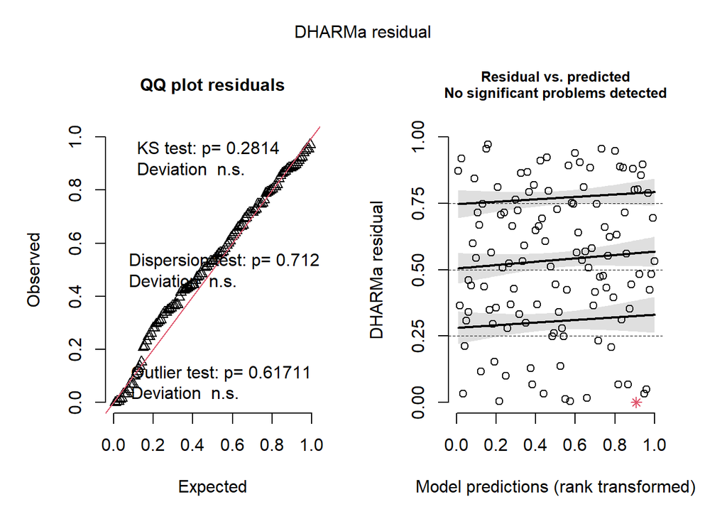

```r
res_beta <- simulateResiduals(beta)
plot(res_beta)
```

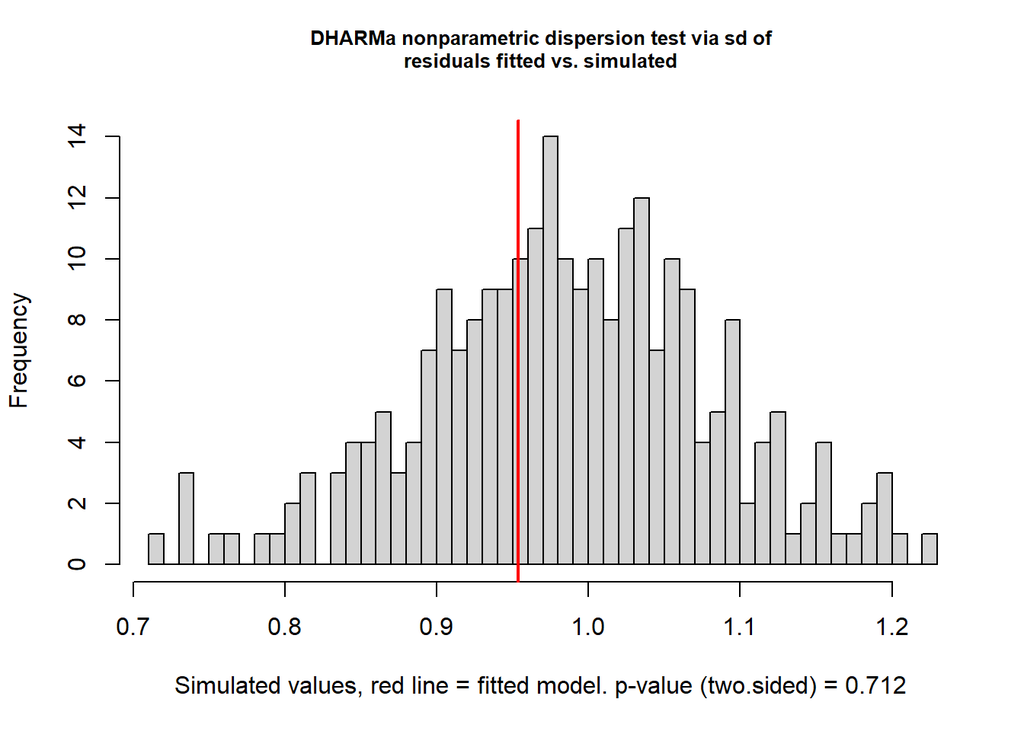

```
##
##  DHARMa nonparametric dispersion test via sd of residuals fitted vs.
##  simulated
##
## data:  simulationOutput
## dispersion = 0.96747, p-value = 0.712
## alternative hypothesis: two.sided
```

```r
testDispersion(res_beta)
```

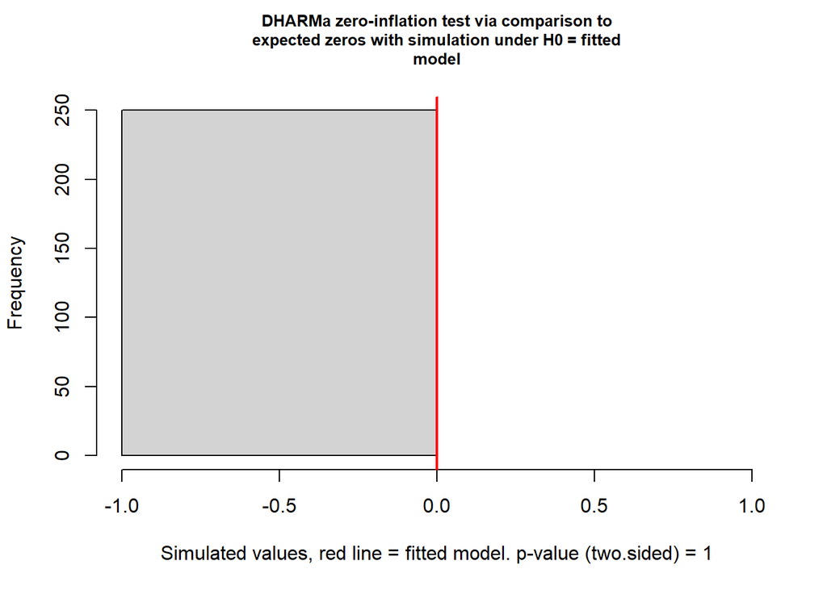

```
##
##  DHARMa zero-inflation test via comparison to expected zeros with
##  simulation under H0 = fitted model
##
## data:  simulationOutput
## ratioObsSim = NaN, p-value = 1
## alternative hypothesis: two.sided
```

```r
testZeroInflation(res_beta)
```

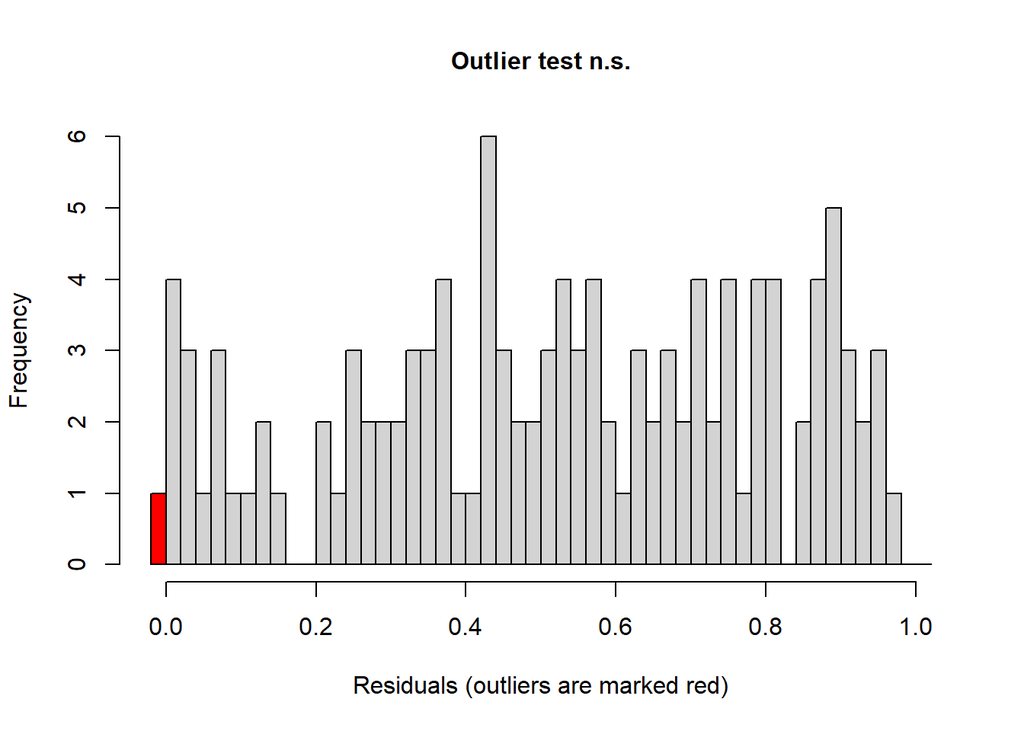

```
##
##  DHARMa outlier test based on exact binomial test with approximate
##  expectations
##
## data:  res_beta
## outliers at both margin(s) = 1, observations = 120, p-value = 0.6171
## alternative hypothesis: true probability of success is not equal to 0.007968127
## 95 percent confidence interval:
##  0.0002109595 0.0455555132
## sample estimates:
## frequency of outliers (expected: 0.00796812749003984 )
##                                            0.008333333
```

```r
testOutliers(res_beta)
```

```r
Anova(beta)
```

```
## Analysis of Deviance Table (Type II Wald chisquare tests)
##
## Response: prop_shelter
##            Chisq Df Pr(>Chisq)
## Treatment 2.1087  2     0.3484
## Body_mass 0.0433  1     0.8352
```

## Plot Shelter Use

```r
# Plotting Time_shelter

# 1) Ensure treatment order
data$Treatment <- factor(
  data$Treatment,
  levels = c("Control", "Low", "High")
)

# 2) Create log-transformed shelter time
# log1p handles zeros safely
data$logTS <- log1p(data$Time_shelter)

# 3) Fit model
m_logTS <- glmmTMB(
  logTS ~ Treatment + Body_mass + (1 | Tank_ID),
  family = gaussian(),
  data = data
)

summary(m_logTS)
```

```
##  Family: gaussian  ( identity )
## Formula:          logTS ~ Treatment + Body_mass + (1 | Tank_ID)
## Data: data
##
##      AIC      BIC   logLik deviance df.resid
##    617.1    635.6   -302.6    605.1      154
##
## Random effects:
##
## Conditional model:
##  Groups   Name        Variance Std.Dev.
##  Tank_ID  (Intercept) 0.09699  0.3114
##  Residual             2.48286  1.5757
## Number of obs: 160, groups:  Tank_ID, 24
##
## Dispersion estimate for gaussian family (sigma^2): 2.48
##
## Conditional model:
##               Estimate Std. Error z value Pr(>|z|)
## (Intercept)     5.5835     0.4528  12.332   <2e-16 ***
## TreatmentLow   -0.1198     0.3424  -0.350   0.7265
## TreatmentHigh   0.1487     0.3426   0.434   0.6642
## Body_mass       1.2272     0.6388   1.921   0.0547 .
## ---
## Signif. codes:  0 '***' 0.001 '**' 0.01 '*' 0.05 '.' 0.1 ' ' 1
```

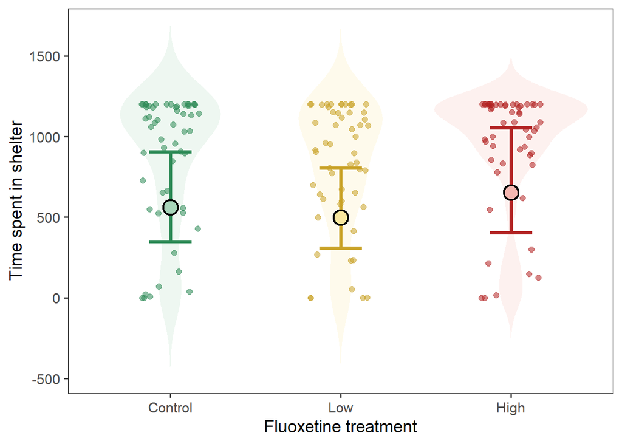

```r
# 4) Get marginal means on the LOG scale
emm_logTS_df <- as.data.frame(emmeans(m_logTS, ~ Treatment))

# 5) Back-transform to original time scale
cn <- names(emm_logTS_df)

mean_col  <- if ("emmean" %in% cn) "emmean" else stop("Can't find emmean column")
lower_col <- dplyr::first(cn[grepl("^lower\\.CL$|^asymp\\.LCL$|^LCL$|^lower$", cn)])
upper_col <- dplyr::first(cn[grepl("^upper\\.CL$|^asymp\\.UCL$|^UCL$|^upper$", cn)])

emm_logTS_df <- emm_logTS_df %>%
  mutate(Treatment = factor(Treatment, levels = c("Control", "Low", "High"))) %>%
  rename(mean_log = !!mean_col, lower_log = !!lower_col, upper_log = !!upper_col) %>%
  mutate(
    mean  = exp(mean_log) - 1,
    lower = exp(lower_log) - 1,
    upper = exp(upper_log) - 1
  )

# 6) Palettes
pastel_cols <- c(
  "Control" = "#A8D5BA",
  "Low"     = "#F9E79F",
  "High"    = "#F5B7B1"
)

dark_cols <- c(
  "Control" = "#2E8B57",
  "Low"     = "#C9A227",
  "High"    = "#B22222"
)

# 7) Plot on original scale
p_shelter <- ggplot() +
  geom_violin(
    data = data,
    aes(x = Treatment, y = Time_shelter, fill = Treatment),
    alpha = 0.20, colour = NA, trim = FALSE
  ) +
  geom_jitter(
    data = data,
    aes(x = Treatment, y = Time_shelter, colour = Treatment),
    width = 0.18, alpha = 0.55, size = 2
  ) +
  geom_errorbar(
    data = emm_logTS_df,
    aes(x = Treatment, ymin = lower, ymax = upper, colour = Treatment),
    width = 0.25, linewidth = 1.3
  ) +
  geom_point(
    data = emm_logTS_df,
    aes(x = Treatment, y = mean, fill = Treatment),
    shape = 21, size = 5, stroke = 1.2, colour = "black"
  ) +
  scale_fill_manual(values = pastel_cols) +
  scale_colour_manual(values = dark_cols) +
  theme_bw(base_size = 14) +
  labs(
    x = "Fluoxetine treatment",
    y = "Time spent in shelter"
  ) +
  theme(
    panel.grid = element_blank(),
    plot.title = element_text(hjust = 0.5),
    legend.position = "none"
  )

ggsave(
  filename = here("figures", "shelter.pdf"),
  plot = p_shelter,
  width = 6,
  height = 5
)

ggsave(
  filename = here("figures", "shelter.jpg"),
  plot = p_shelter,
  width = 6,
  height = 5,
  dpi = 600
)

p_shelter
```

## Model freezing time

Fit a Tweedie generalised linear mixed-effects model for time spent not moving, used here as the measure of freezing behaviour. Treatment and body mass are included as fixed effects and tank as a random intercept. Simulation-based residual checks are performed before evaluating the overall treatment effect.

```r
## Time_freezing
# Family: Tweedie
m1_time_not_moving <- glmmTMB(Time_not_moving ~ Treatment + Body_mass + (1 | Tank_ID),
  data = data,
  family = tweedie(link = "log"))

summary(m1_time_not_moving)
```

```
##  Family: tweedie  ( log )
## Formula:          Time_not_moving ~ Treatment + Body_mass + (1 | Tank_ID)
## Data: data
##
##      AIC      BIC   logLik deviance df.resid
##   1872.5   1894.0   -929.2   1858.5      153
##
## Random effects:
##
## Conditional model:
##  Groups  Name        Variance Std.Dev.
##  Tank_ID (Intercept) 0.08849  0.2975
## Number of obs: 160, groups:  Tank_ID, 24
##
## Dispersion parameter for tweedie family (): 12.6
##
## Conditional model:
##               Estimate Std. Error z value Pr(>|z|)
## (Intercept)     5.8661     0.3916  14.979   <2e-16 ***
## TreatmentLow    0.2252     0.2991   0.753    0.452
## TreatmentHigh  -0.1634     0.3074  -0.532    0.595
## Body_mass      -0.6305     0.5484  -1.150    0.250
## ---
## Signif. codes:  0 '***' 0.001 '**' 0.01 '*' 0.05 '.' 0.1 ' ' 1
```

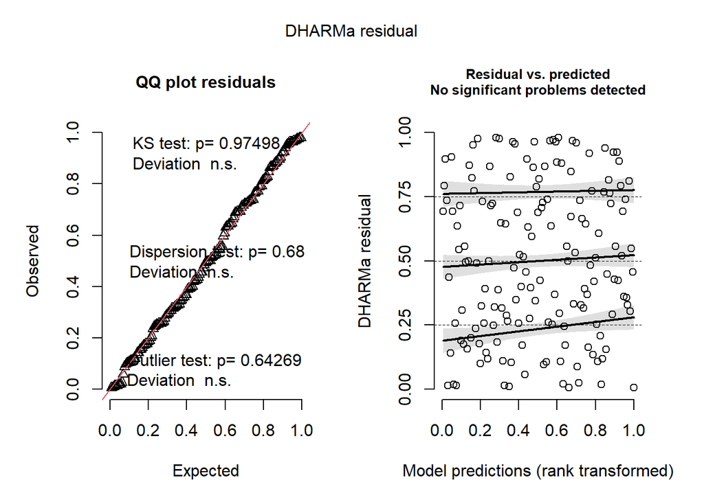

```r
# Diagnosis
res_m1_time_not_moving <- simulateResiduals(m1_time_not_moving)
plot(res_m1_time_not_moving)
```

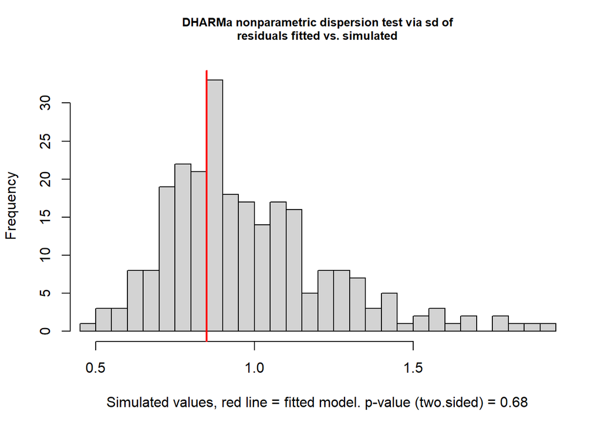

```
##
##  DHARMa nonparametric dispersion test via sd of residuals fitted vs.
##  simulated
##
## data:  simulationOutput
## dispersion = 0.86705, p-value = 0.68
## alternative hypothesis: two.sided
```

```r
testDispersion(res_m1_time_not_moving)
```

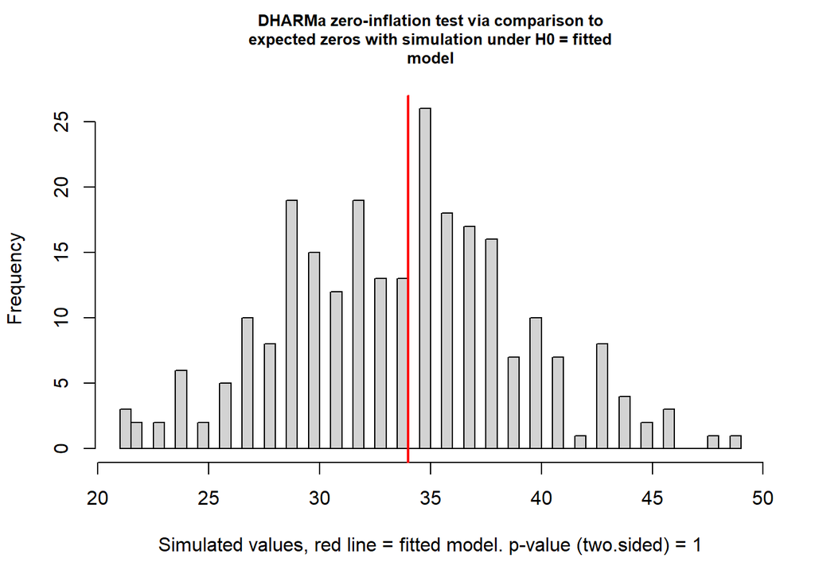

```
##
##  DHARMa zero-inflation test via comparison to expected zeros with
##  simulation under H0 = fitted model
##
## data:  simulationOutput
## ratioObsSim = 1.0041, p-value = 1
## alternative hypothesis: two.sided
```

```r
testZeroInflation(res_m1_time_not_moving)
```

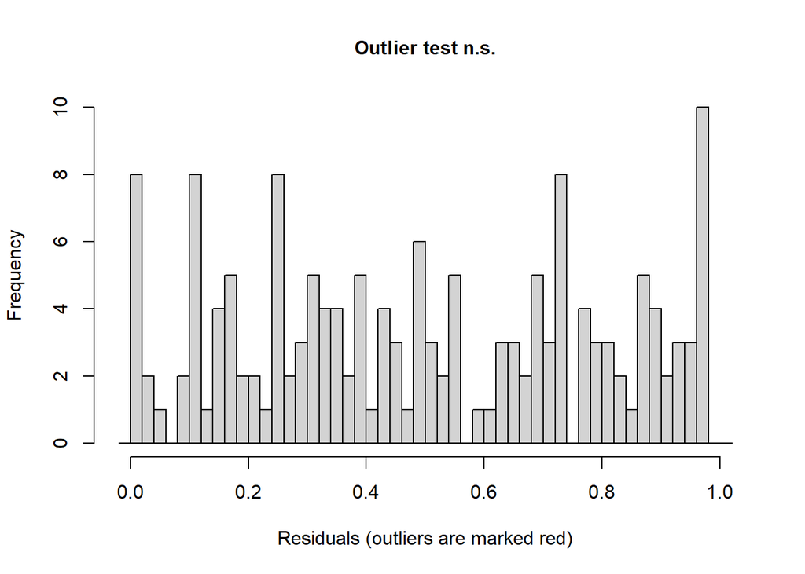

```
##
##  DHARMa outlier test based on exact binomial test with approximate
##  expectations
##
## data:  res_m1_time_not_moving
## outliers at both margin(s) = 0, observations = 160, p-value = 0.6427
## alternative hypothesis: true probability of success is not equal to 0.007968127
## 95 percent confidence interval:
##  0.00000000 0.02279175
## sample estimates:
## frequency of outliers (expected: 0.00796812749003984 )
##                                                      0
```

```r
testOutliers(res_m1_time_not_moving)
```

```r
# Anova of the model
Anova(m1_time_not_moving)
```

```
## Analysis of Deviance Table (Type II Wald chisquare tests)
##
## Response: Time_not_moving
##            Chisq Df Pr(>Chisq)
## Treatment 1.6556  2     0.4370
## Body_mass 1.3218  1     0.2503
```

## Plot freezing time

```r
## Time_not_moving (freezing time)

# 1) Ensure treatment order
data$Treatment <- factor(
  data$Treatment,
  levels = c("Control", "Low", "High")
)

# 2) Fit Tweedie model
m1_time_not_moving <- glmmTMB(
  Time_not_moving ~ Treatment + Body_mass + (1 | Tank_ID),
  data = data,
  family = tweedie(link = "log")
)

summary(m1_time_not_moving)
```

```
##  Family: tweedie  ( log )
## Formula:          Time_not_moving ~ Treatment + Body_mass + (1 | Tank_ID)
## Data: data
##
##      AIC      BIC   logLik deviance df.resid
##   1872.5   1894.0   -929.2   1858.5      153
##
## Random effects:
##
## Conditional model:
##  Groups  Name        Variance Std.Dev.
##  Tank_ID (Intercept) 0.08849  0.2975
## Number of obs: 160, groups:  Tank_ID, 24
##
## Dispersion parameter for tweedie family (): 12.6
##
## Conditional model:
##               Estimate Std. Error z value Pr(>|z|)
## (Intercept)     5.8661     0.3916  14.979   <2e-16 ***
## TreatmentLow    0.2252     0.2991   0.753    0.452
## TreatmentHigh  -0.1634     0.3074  -0.532    0.595
## Body_mass      -0.6305     0.5484  -1.150    0.250
## ---
## Signif. codes:  0 '***' 0.001 '**' 0.01 '*' 0.05 '.' 0.1 ' ' 1
```

```r
# 3) Estimated marginal means on response scale
emm_freezing <- as.data.frame(
  emmeans(m1_time_not_moving, ~ Treatment, type = "response")
)

print(emm_freezing)
```

```
##  Treatment response       SE  df asymp.LCL asymp.UCL
##  Control   240.0762 52.46413 Inf  156.4354  368.4369
##  Low       300.7018 64.84490 Inf  197.0510  458.8742
##  High      203.8829 46.48503 Inf  130.4091  318.7525
##
## Confidence level used: 0.95
## Intervals are back-transformed from the log scale
```

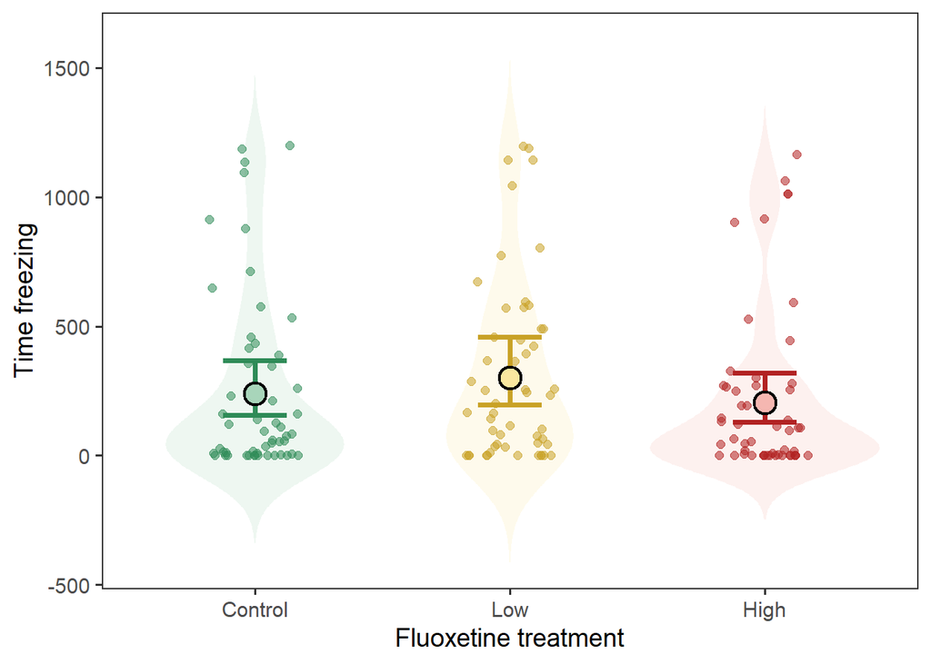

```r
# 4) Standardise column names
cn <- names(emm_freezing)

mean_col  <- dplyr::first(cn[cn %in% c("response", "rate", "emmean")])
lower_col <- dplyr::first(cn[grepl("^lower\\.CL$|^asymp\\.LCL$|^LCL$|^lower$", cn)])
upper_col <- dplyr::first(cn[grepl("^upper\\.CL$|^asymp\\.UCL$|^UCL$|^upper$", cn)])

if (is.na(mean_col) || is.na(lower_col) || is.na(upper_col)) {
  stop("Could not identify mean/CI columns in emmeans output. Run names(emm_freezing).")
}

emm_freezing <- emm_freezing %>%
  mutate(Treatment = factor(Treatment, levels = c("Control", "Low", "High"))) %>%
  rename(
    mean  = !!mean_col,
    lower = !!lower_col,
    upper = !!upper_col
  )

# 5) Colour palettes
pastel_cols <- c(
  "Control" = "#A8D5BA",
  "Low"     = "#F9E79F",
  "High"    = "#F5B7B1"
)

dark_cols <- c(
  "Control" = "#2E8B57",
  "Low"     = "#C9A227",
  "High"    = "#B22222"
)

# 6) Plot
p_freezing <- ggplot() +
  geom_violin(
    data = data,
    aes(x = Treatment, y = Time_not_moving, fill = Treatment),
    alpha = 0.20,
    colour = NA,
    trim = FALSE
  ) +
  geom_jitter(
    data = data,
    aes(x = Treatment, y = Time_not_moving, colour = Treatment),
    width = 0.18,
    alpha = 0.55,
    size = 2
  ) +
  geom_errorbar(
    data = emm_freezing,
    aes(x = Treatment, ymin = lower, ymax = upper, colour = Treatment),
    width = 0.25,
    linewidth = 1.3
  ) +
  geom_point(
    data = emm_freezing,
    aes(x = Treatment, y = mean, fill = Treatment),
    shape = 21,
    size = 5,
    stroke = 1.2,
    colour = "black"
  ) +
  scale_fill_manual(values = pastel_cols) +
  scale_colour_manual(values = dark_cols) +
  theme_bw(base_size = 14) +
  labs(
    x = "Fluoxetine treatment",
    y = "Time freezing"
  ) +
  theme(
    panel.grid = element_blank(),
    legend.position = "none"
  )

print(p_freezing)
```

```r
ggsave(
  filename = here("figures", "Freezing.pdf"),
  plot = p_freezing,
  width = 6,
  height = 5
)

ggsave(
  filename = here("figures", "Freezing.jpg"),
  plot = p_freezing,
  width = 6,
  height = 5,
  dpi = 600
)
```

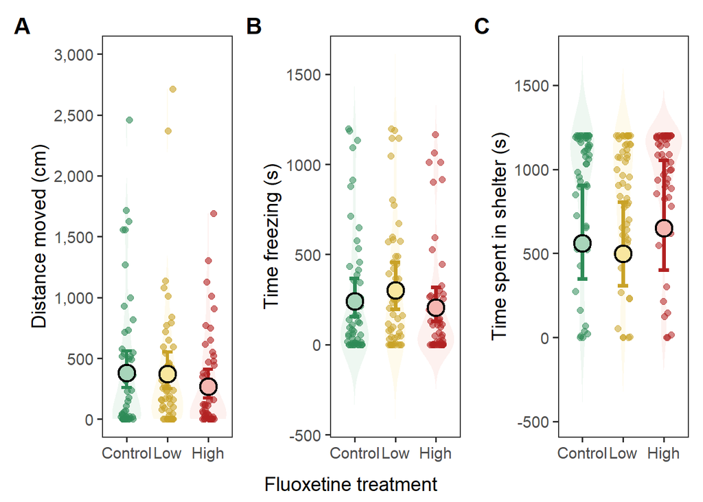

```r
#Figure 1
# Remove repeated x-axis titles from individual plots
p_distance_clean <- p_distance +
  labs(x = NULL, y = "Distance moved (cm)") +
  theme(
    axis.text.x = element_text(angle = 0, hjust = 0.5),
    plot.margin = margin(5, 5, 5, 5)
  )

p_freezing_clean <- p_freezing +
  labs(x = NULL, y = "Time freezing (s)") +
  theme(
    axis.text.x = element_text(angle = 0, hjust = 0.5),
    plot.margin = margin(5, 5, 5, 5)
  )

p_shelter_clean <- p_shelter +
  labs(x = NULL, y = "Time spent in shelter (s)") +
  theme(
    axis.text.x = element_text(angle = 0, hjust = 0.5),
    plot.margin = margin(5, 5, 5, 5)
  )

# Combine plots
figure_behaviour <- (
  p_distance_clean + p_freezing_clean + p_shelter_clean
) +
  plot_annotation(
    tag_levels = "A",
    caption = "Fluoxetine treatment"
  ) &
  theme(
    plot.tag = element_text(size = 16, face = "bold"),
    plot.caption = element_text(size = 14, hjust = 0.5),
    legend.position = "none"
  )

figure_behaviour
```

```r
ggsave(
  filename = here("figures", "behaviour_figure.pdf"),
  plot = figure_behaviour,
  width = 12,
  height = 4.5
)

ggsave(
  filename = here("figures", "behaviour_figure.jpg"),
  plot = figure_behaviour,
  width = 12,
  height = 4.5,
  dpi = 600
)
```